# ¶ TP2 ¶

La Régression Logistique

Guilherme & Clémence : Esiee Paris 2022-2023

#### 1 Introduction

L’objectif du TD est de réaliser une régression logistique multivariée et de mettre en place différentes étapes pour évaluer la pertinence des variables et sélectionner celles qui sont pertinentes. Les différentes étapes sont : * Réaliser une régression logistique sur un modèle plein (avec toutes les variables) * Utiliser le test de Wald sur une ou plusieurs variables pour évaluer leur pertinence au sein du modèle * Réaliser et interpréter une courbe ROC afin de déterminer un seuil optimal. * Réaliser une régression logistique progressive afin de sélectionner les variables pertinentes * Réaliser sur les variables sélectionnées à partir de la régression ascendente, une régression logistique en validation croisée qui nous permettra, sur l’ensemble des jeux tests, d’estimer un seuil moyen “optimal”.

##### 1.1. Les librairies

- Les librairies nécessaires sont : ggplot2, caret, readr, pROC, reshape2, MASS, aod et kableExtra.

##### 1.2. Les données

```r
dfw <- read.csv("Hearh_clinical_records_dataset.csv")

#Formatage des données
names(dfw)[c(3,5,6,8,9,13)] <- c('cpk','frac', 'hbp', 'creat', 'Na','event')

dfw$age <- round(dfw$age,digits = 0)
dfw$sex <- factor(dfw$sex, levels = c(0,1), labels = c('F','H'))
dfw$smoking <- factor(dfw$smoking, levels = c(0,1), labels = c('Non','Oui'))
dfw$diabetes <- factor(dfw$diabetes, levels = c(0,1), labels = c('Non','Oui'))
dfw$hbp <- factor(dfw$hbp, levels = c(0,1), labels = c('Non','Oui'))
dfw$event <- factor(dfw$event, levels = c(0,1), labels = c('dcd','vv'))
dfw$anaemia <- factor(dfw$anaemia, levels = c(0,1), labels = c('Non', 'Oui'))

new_df <- data.frame(dfw[1], dfw$cpk, dfw$frac, dfw$platelets, dfw$creat, dfw$Na, dfw$time, dfw$anaemia, dfw$diabetes, dfw$hbp, dfw$smoking, dfw$sex, dfw$event)
names(new_df) <- c("age", "cpk", "frac", "platelets", "creat", "Na", "time", "anaemia", "diabetes", "hbp", "smoking", "sex", "event")
head(new_df) %>% kbl() %>%  kable_styling( position = "center", full_width = FALSE)
```

| age | cpk | frac | platelets | creat | Na | time | anaemia | diabetes | hbp | smoking | sex | event |
| --- | --- | --- | --- | --- | --- | --- | --- | --- | --- | --- | --- | --- |
| 75 | 582 | 20 | 265000 | 1.9 | 130 | 4 | Non | Non | Oui | Non | H | vv |
| 55 | 7861 | 38 | 263358 | 1.1 | 136 | 6 | Non | Non | Non | Non | H | vv |
| 65 | 146 | 20 | 162000 | 1.3 | 129 | 7 | Non | Non | Non | Oui | H | vv |
| 50 | 111 | 20 | 210000 | 1.9 | 137 | 7 | Oui | Non | Non | Non | H | vv |
| 65 | 160 | 20 | 327000 | 2.7 | 116 | 8 | Oui | Oui | Non | Non | F | vv |
| 90 | 47 | 40 | 204000 | 2.1 | 132 | 8 | Oui | Non | Oui | Oui | H | vv |

On commence par identifier la variable à prédire “event” dans le dataframe “new_df” et le stocke dans la variable “id_pred”.

#### 2 Regression logistique multivariée

```r
#-> recherche automatique de l'identifiant de la variable à prédire
pred_name <- 'event'
id_pred   <- which(names(new_df) %in% pred_name)
#-> on renomme de dataframe
XY        <- new_df
X <- XY[1:6]
Y <- XY[7:12]
#-> construction du modèle
#full_form  <- as.formula(paste0(names(dfw)[id_pred], ' ~ ',paste0(names(dfw)[-id_pred], collapse = ' + ')))
#-> rmq : on aurait pu aussi utiolser une formule bcp plus simple ( mais moins lisible)
# ..... ful_form <- as.formula('event ~.')
#-> on appelle la règression logistique (qui est un modèle linéaire général)
full_model <- glm(event ~., family=binomial(link=logit), data = new_df)
```

```r
summary(full_model)
```

```
##
## Call:
## glm(formula = event ~ ., family = binomial(link = logit), data = new_df)
##
## Deviance Residuals:
##     Min       1Q   Median       3Q      Max
## -2.1849  -0.5705  -0.2399   0.4465   2.6671
##
## Coefficients:
##               Estimate Std. Error z value Pr(>|z|)
## (Intercept)  1.018e+01  5.657e+00   1.800 0.071866 .
## age          4.748e-02  1.580e-02   3.004 0.002661 **
## cpk          2.224e-04  1.780e-04   1.249 0.211510
## frac        -7.668e-02  1.633e-02  -4.695 2.66e-06 ***
## platelets   -1.201e-06  1.889e-06  -0.635 0.525106
## creat        6.661e-01  1.815e-01   3.670 0.000242 ***
## Na          -6.698e-02  3.974e-02  -1.686 0.091882 .
## time        -2.105e-02  3.015e-03  -6.982 2.91e-12 ***
## anaemiaOui  -7.741e-03  3.605e-01  -0.021 0.982869
## diabetesOui  1.451e-01  3.512e-01   0.413 0.679503
## hbpOui      -1.028e-01  3.587e-01  -0.286 0.774528
## smokingOui  -1.335e-02  4.127e-01  -0.032 0.974182
## sexH        -5.340e-01  4.139e-01  -1.290 0.197051
## ---
## Signif. codes:  0 '***' 0.001 '**' 0.01 '*' 0.05 '.' 0.1 ' ' 1
##
## (Dispersion parameter for binomial family taken to be 1)
##
##     Null deviance: 375.35  on 298  degrees of freedom
## Residual deviance: 219.53  on 286  degrees of freedom
## AIC: 245.53
##
## Number of Fisher Scoring iterations: 6
```

*Les résultats ci-dessus donnent les coefficients estimés pour chaque variable explicative, leur erreur standard, la valeur z, le p-value et le niveau de signification (indiqué par des astérisques).*

Interprétation

- La p-value est une mesure contre l’hypothèse nulle. Plus la p-value est faible, plus l’hypothèse nulle est forte. Dans ce modèle, les variables “age”, “frac”, “creat” et “time” sont significatives, car leur p-value est inférieure à 0,05.
- L’AIC (Akaike Information Criterion) mesure de la qualité du modèle qui prend en compte la complexité du modèle et la qualité de l’ajustement. Un AIC plus faible indique un meilleur ajustement du modèle. Dans notre modèle, l’AIC est de 245,53, ce qui suggère que le modèle est relativement bien ajusté.
- Les Deviance Residuals nous apportent des précisions sur la différence entre les valeurs observées et les valeurs prédites par le modèle, ajustées pour le nombre de degrés de liberté du modèle. Pour notre modèle les Deviance Residuals montrent que la distribution des résidus est symétrique et centrée sur zéro, ce qui est une bonne indication d’un ajustement correct du modèle cependant, le fait que les valeurs maximales et minimales soient assez éloignées de zéro peut suggérer que le modèle ne prédit pas correctement les cas extrêmes.

##### 2.1. Coefficents de régression

Les résultats qui sont présentés dans la section 2.1 montrent les coefficients de régression pour chaque variable dans le modèle. Les coefficients indiquent la variation de l’odds ratio associée à un changement d’une unité dans la variable indépendante correspondante.

##### 2.1.1 Inférence statistique

- Sous hypothèse de normalité les z scores (colonne 3) : Z=β^s/(βj) → N(0,1) suivent une distribution normale.
- Il est donc possible de réaliser une inférence permettant de tester, pour chaque variable, leur degrés de signification (de participation) dans le modèle .

L’inférence est la suivante :

{H0:βj=0 {H1:βj≠0

- L’acceptation de H0 signifie que la variable ne participe pas de façon significative à l’estimation de y. Ce test nous fournit une première indication sur l’implication des variables dans l’estimation de la variable à expliquer. Cependant, ce test ne fournit pas de renseignements sur l’apport d’une variable par rapport aux autres dans l’estimation de la variable à expliquer. Il est donc nécessaire de réaliser un test de Wald.

##### 2.1.2 Intervalle de confiance

- La fonction confint.default permet de calculer les limites l’intervalle de confiance en bilatéral (95%) associé aux paramètres de la régression.

```r
head(confint.default(full_model) )  %>% kbl(booktabs = TRUE) %>% kable_styling( position = "center", full_width = FALSE)
```

|  | 2.5 % | 97.5 % |
| --- | --- | --- |
| (Intercept) | -0.9050470 | 21.2688451 |
| age | 0.0165063 | 0.0784597 |
| cpk | -0.0001265 | 0.0005712 |
| frac | -0.1086869 | -0.0446704 |
| platelets | -0.0000049 | 0.0000025 |
| creat | 0.3103914 | 1.0218718 |

On observe ci-dessus les intervalles de confiance pour chaque coefficient de régression. Ces intervalles donnent une estimation de la plage de valeurs dans laquelle le vrai coefficient se situe avec un certain niveau de confiance (ici, 95%). Par exemple, pour l’âge, l’intervalle de confiance à 95% est de [0,0165063 ; 0,0784597], ce qui signifie que l’on peut être sûr à 95% que le vrai coefficient se situe dans cet intervalle.

##### 2.2. Test de Wald

- Le test de Wald permet de realiser différents tests sur les coefficients des variables en prenant en compte le lien (matrice des variances covariance) entre ces dernières. A titre d’exemple nous testons s’il existe une différence entre les coefficients age et Na. Nous affectons le code 1 pour l’age et - 1 pour Na, car nous testons une différence (cette méthode est appelée méthode des constrastes):

```r
 t <- rbind(rep(0,13)) ; t[2] <- 1 ; t[7] <- -1
 wald.test ( b  =  coef (full_model),  Sigma  =  vcov (full_model),  L  = t)
```

```
## Wald test:
## ----------
##
## Chi-squared test:
## X2 = 7.3, df = 1, P(> X2) = 0.007
```

```r
 wald.test ( b  =  coef (full_model),  Sigma  =  vcov (full_model),  Terms  = c(4,7))
```

```
## Wald test:
## ----------
##
## Chi-squared test:
## X2 = 25.0, df = 2, P(> X2) = 3.7e-06
```

##### 2.3. Performance du classifieur

- La courbe ROC permet d’évaluer les performances d’un classifieur binaire, c’est-à-dire d’un système qui a pour objectif de catégoriser des éléments en deux groupes distincts sur la base d’une ou plusieurs des caractéristiques de chacun de ces éléments. Un article intéressant sur les applications de la courbe ROC en biologie ici
- La courbe ROC est une représentation graphique de la relation existante entre la sensibilité et la spécificité d’un test pour toutes les valeurs seuils possibles. L’ordonnée représente la sensibilité et l’abscisse correspond à la quantité (1- spécificité).
- De manière synthétique il s’agit de tracer l’évolution en fonction des seuils de la proportion entre vrais positifs et la proportion de faux positifs. Si la relation entre les deux proportions est égale à 1 (droite) l’AUC = 0.5. Dans ces conditions, la proportion entre vrais positifs et faux positifs sera identique et le prédicteur (algorithme : reg logistique pas exemple) ne fera pas mieux que le hasard. Plus l’aire sous courbe sera supérieure à 0.5, plus l’algoritme sera plus performant : % de détection des VP > % de détection des FP.
- Un des apports majeurs de la courbe ROC est la possibilité de calculer le seuil optimal de détection (vv versus dcd). Ce dernier est essentiel pour le calcul de la matrice des confusions et donc pour l’évaluation des performances de l’algoritme (régression logistique dans notre cas). Il existe plusieurs indices permettant de calculer les seuils. Nous utiliserons l’indice de Youden qui est simple à calculer et performant (cf. cours). Ce dernier correspond au point de la courbe le plus éloigné de la diagonale (AUC = 0.5).
- Cepandant, la recherche du seuil (choix de l’indice) néssecite la prise en compte de données épidémiologiques.
- la prévalence (% de vivant : annotations ) ne doit pas trop s’éloigner de 50%.
- L’intéret médicaux économique : A titre d’exemple : Si une maladie possède un traitement onéreux aux effets secondaires potentiellement graves, il convient de limiter au maximum le nombre de faux positifs, donc de choisir une spécificité élevée. La valeur seuil sera située dans ce cas dans la partie inférieure gauche de la courbe ROC. À l’inverse, certaines maladies possèdent des complications graves qui peuvent être évitées si un traitement simple est mis en place précocement : le test doit posséder une sensibilité élevée. La valeur seuil se situera au niveau de la partie supérieure droite de la courbe ROC.

##### 2.4. Courbe Sen Spe vs seuil

###### 2.4.1 Script

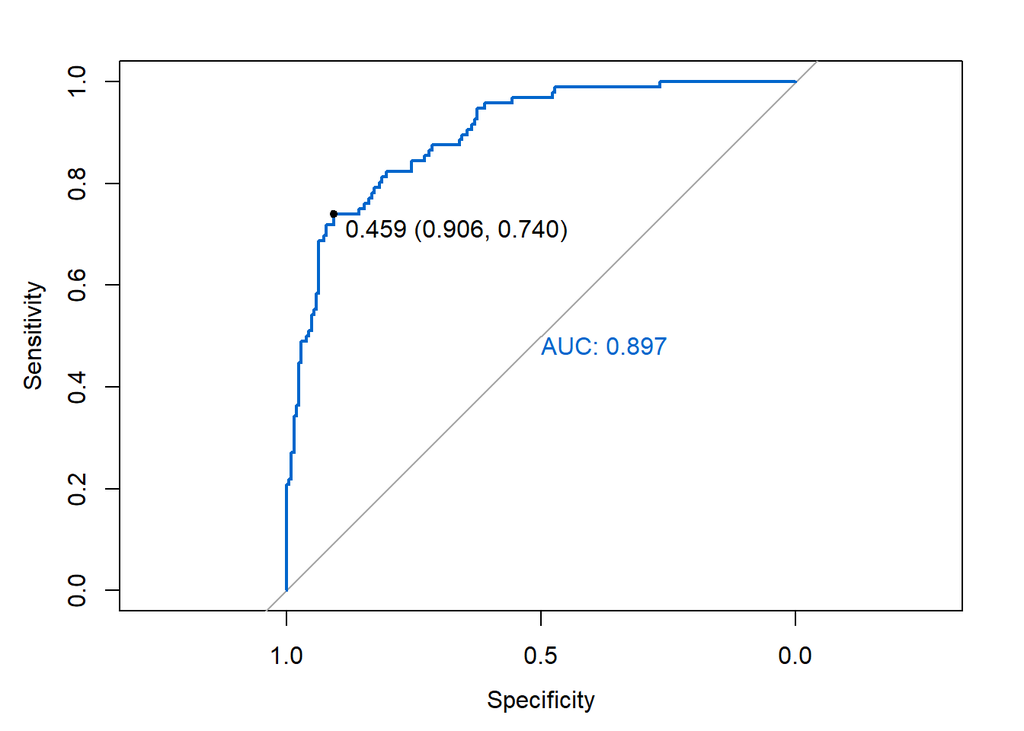

```r
Valid_ROC <- function(obs, pred, direction = 0, threshold  = NULL, graph = T)
{
  require(pROC)
  require(caret)
  if(!is.factor(obs)){obs <- factor(obs)}
  lev        <- levels(obs)
  data_logit <- data.frame(obs = factor(obs), pred = pred)
  data_roc   <- roc(obs,pred)
  cir        <- ci(data_roc)
  data_spec  <- data.frame( sens    = data_roc$sensitivities ,
                            spec    = data_roc$specificities ,
                            thr     = data_roc$thresholds    ,
                            youden  = data_roc$sensitivities + data_roc$specificities - 1
                           )
  cir <- data.frame(roc = c(cir, youden = max(data_spec$youden) )) ; rownames(cir) <-c('AUC_lower','AUC','AUC_upper','youden')
  #-> si argument nulle alors calcul du seuil par la méthode de Youden
  if (is.null(threshold))
  {
    id       <- which.max(data_spec$youden) ; data_spec[id,] ;
    best_thr <- data_spec[id,3]
  }else{best_thr <- threshold}
  #-> binarisation
  if(direction == 0){dir_name <- lev[1] ; ndir_name <- lev[2] }else{dir_name = lev[2] ; ndir_name <- lev[1]}
  fac_roc    <- rep(dir_name,nrow(data_logit))
  id         <- which(pred >= best_thr) ; fac_roc[id] <- ndir_name ; fac_roc <- factor(fac_roc)
  conf_mat_1 <- confusionMatrix(fac_roc, obs)
  result     <- data.frame(Confusion = c(                 conf_mat_1$overall[1],
                                                          conf_mat_1$overall[3],
                                                          conf_mat_1$overall[4],
                                                          conf_mat_1$byClass[1],
                                                          conf_mat_1$byClass[2],
                                                          conf_mat_1$byClass[3],
                                                          conf_mat_1$byClass[4],
                                                          conf_mat_1$byClass[7],
                                                          Threshold  = best_thr
                                          )
                         )
  all_result <- list( result = result, Confusion = conf_mat_1$table, roc = cir)
  #--> graphique
  if(graph)
    {  data_gr    <- melt(data_spec, id.vars = 'thr')
       gr         <- ggplot(data = data_gr) + geom_line(aes(x = thr, y = value, color = variable )) +
       ylab('Probability') + xlab('threshold') + theme(legend.title = element_blank()) + geom_vline( xintercept = best_thr, color = '#0066CC')
      #--> courbe roc
      plot.roc(data_roc, print.auc=TRUE, print.thres=TRUE,col="#0066CC")
      all_result[['graph']] <- gr
  }
      return( all_result)
}
result <- Valid_ROC(XY$event, full_model$fitted.values, graph = T)
```

* graph (i) il fournit la courbe ROC avec l’AUC, la valeur du seuil (+ IC) calculé à partie de l’indice de Youden

*La fonction Valid_ROC utilise les librairies pROC et caret.Elle permet de calculer les performances d’un modèle de classification binaire en utilisant la courbe ROC (Receiver Operating Characteristic) ainsi que les métriques de performance telles que la sensibilité, la spécificité et la valeur prédictive positive et négative. Elle permet également de déterminer le seuil optimal pour la classification binaire en utilisant la méthode de Youden. Enfin, elle génère un graphique de la courbe ROC et des métriques de performance associées.*

###### 2.4.2 Résultats

```r
kable(result$roc,align = rep("c", ncol(result$roc))) %>%
  kable_styling(bootstrap_options = "striped", full_width = F, position = "center")
```

|  | roc |
| --- | --- |
| AUC_lower | 0.8609673 |
| AUC | 0.8972188 |
| AUC_upper | 0.9334703 |
| youden | 0.6459873 |

- $roc contient les résultats de l’analyse ROC, y compris l’aire sous la courbe (AUC) de la courbe ROC, les bornes inférieure et supérieure de l’AUC, ainsi que le seuil de classification optimal basé sur la méthode Youden.

```r
kable(result$result,align = rep("c", ncol(result$result))) %>%
  kable_styling(bootstrap_options = "striped", full_width = F, position = "center")
```

|  | Confusion |
| --- | --- |
| Accuracy | 0.8528428 |
| AccuracyLower | 0.8075265 |
| AccuracyUpper | 0.8909955 |
| Sensitivity | 0.9064039 |
| Specificity | 0.7395833 |
| Pos Pred Value | 0.8803828 |
| Neg Pred Value | 0.7888889 |
| F1 | 0.8932039 |
| Threshold | 0.4593004 |

- result$result contient les mesures de performance du modèle, telles que l’exactitude, la sensibilité, la spécificité, la valeur prédictive positive et négative, ainsi que la F1-score et le seuil choisi pour binariser les prévisions.

```r
kable(result$Confusion,align = rep("c", ncol(result$Confusion))) %>%
  kable_styling(bootstrap_options = "striped", full_width = F, position = "center")
```

|  | dcd | vv |
| --- | --- | --- |
| dcd | 184 | 25 |
| vv | 19 | 71 |

- $Confusion est une matrice de confusion pour le modèle, donnant le nombre d’observations correctement classées et mal classées pour chaque niveau de la variable de réponse et de la variable prédite au seuil optimal.

Si on interprète ces résultats, on peut dire que l’aire sous la courbe ROC est de 0,897, ce qui indique une performance globalement bonne du modèle. Les autres mesures de performance incluent une exactitude de 0,85, une sensibilité de 0,91 et une spécificité de 0,74. La matrice de confusion indique que le modèle a correctement classé 255 des 299 observations.

- Les graphiques

*graph (ii), il fournit l’évolution des spécificités et des sensibilités an fonction des valeurs de seuil. Il montre aussi l’évolution de l’indice de Youden en fonction des seuils.*

+*Dans le cadre de cette analyse, l’indice Youden privilégie la spécificité au profil de la sensibilité. Il est bien évidemment possible de modifier le seuil en fonction des priorités de l’étude (privilégier le sensibilité ou la spécificité, ou un “équilibre” entre les deux)*

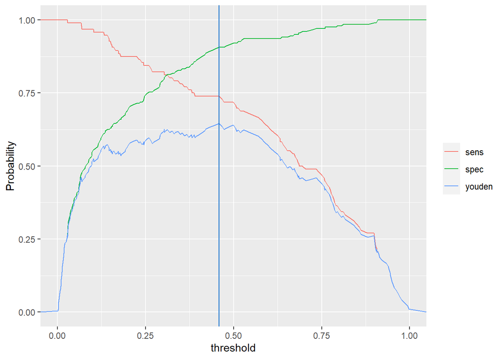

```r
result$graph
```

#### 3 Regression logistique ascendente

##### 3.1. Rappels

- Comme nous l’avons vu lors de l’analyse des z scores, certains coefficients des variables ne semblent pas pertinents (non significatifs).
- La sélection progressive des variables se fait en calculant le rapport de vraisemblance entre les modéles à p variables et p + 1 variables. Aprés avoir calculer le rapport, on validera l’inclusion de la nouvelle variable à l’aide d’un test de Wald. Si le test conclue à une acceptation H0 (egalité des modèles à p et p +1 variable), l’apport de la variable (en terme du rapport de vraisemblance) est faible et donc la variable n’améliorera pas la prédiction. En conséquence, elle ne sera pas rajoutée au modèle.
- La fonction stepAIC du package MASS réalise automatiquemnt la procédure d’inclusion et fournit le modèle avec les variables retenues (donc pertinentes pour l’estimation de la prédiction)

##### 3.2. Description de la méthode

- L’utilisation de la fonction stepAIC nécessite en amont quelques calculs préliminaires
- la mise en forme des modéles plein et modèles vides en utilisant la fonction as.formula que nous avons déjà utilisé au paragraphe 2 (pour le modèle plein)
- Le calcul des régressions logistiques sur le modèle vide et le modèle plein. Le code est le suivant :

```r
empty_form    <- as.formula(paste0(names(dfw)[id_pred] ,'~1'))
 full_form     <- as.formula(paste0(names(dfw)[id_pred], ' ~ ', paste0(names(dfw)[-id_pred], collapse = ' + ')))
 empty_model   <- glm(empty_form , family=binomial(link=logit), data = XY)
 full_model    <- glm(full_form  , family=binomial(link=logit), data = XY)
 forward_model <-  stepAIC(empty_model,direction = 'forward',  scope = list(upper = full_model), trace = F)
 summary(forward_model)
```

```
##
## Call:
## glm(formula = event ~ time + frac + creat + age + Na, family = binomial(link = logit),
##     data = XY)
##
## Deviance Residuals:
##     Min       1Q   Median       3Q      Max
## -2.1590  -0.5887  -0.2281   0.5143   2.7963
##
## Coefficients:
##              Estimate Std. Error z value Pr(>|z|)
## (Intercept)  9.489772   5.405875   1.755  0.07918 .
## time        -0.020897   0.002916  -7.166 7.73e-13 ***
## frac        -0.073443   0.015787  -4.652 3.28e-06 ***
## creat        0.686028   0.174051   3.942 8.10e-05 ***
## age          0.042523   0.015033   2.829  0.00467 **
## Na          -0.064555   0.038379  -1.682  0.09256 .
## ---
## Signif. codes:  0 '***' 0.001 '**' 0.01 '*' 0.05 '.' 0.1 ' ' 1
##
## (Dispersion parameter for binomial family taken to be 1)
##
##     Null deviance: 375.35  on 298  degrees of freedom
## Residual deviance: 223.47  on 293  degrees of freedom
## AIC: 235.47
##
## Number of Fisher Scoring iterations: 6
```

###### 3.2.1 Résultats

```r
result_forward <- Valid_ROC(XY$event, forward_model$fitted.values, graph = F)
```

Nous pouvons maintenant étudier la qualité de l’ajustement avec le modèle forward.

- L’AUC :

```r
kable(result_forward$roc,align = rep("c", ncol(result_forward$roc))) %>%
  kable_styling(bootstrap_options = "striped", full_width = F, position = "center")
```

|  | roc |
| --- | --- |
| AUC_lower | 0.8557927 |
| AUC | 0.8935242 |
| AUC_upper | 0.9312557 |
| youden | 0.6635878 |

- La matrice des confusions au seuil optimal :

```r
kable(result_forward$Confusion,align = rep("c", ncol(result_forward$Confusion))) %>%
  kable_styling(bootstrap_options = "striped", full_width = F, position = "center")
```

|  | dcd | vv |
| --- | --- | --- |
| dcd | 177 | 20 |
| vv | 26 | 76 |

- Spécificité et Sensibilité :

```r
kable(result_forward$result,align = rep("c", ncol(result_forward$result))) %>%
  kable_styling(bootstrap_options = "striped", full_width = F, position = "center")
```

|  | Confusion |
| --- | --- |
| Accuracy | 0.8461538 |
| AccuracyLower | 0.8001752 |
| AccuracyUpper | 0.8851110 |
| Sensitivity | 0.8719212 |
| Specificity | 0.7916667 |
| Pos Pred Value | 0.8984772 |
| Neg Pred Value | 0.7450980 |
| F1 | 0.8850000 |
| Threshold | 0.3902202 |

###### 3.2.2 Courbe ROC

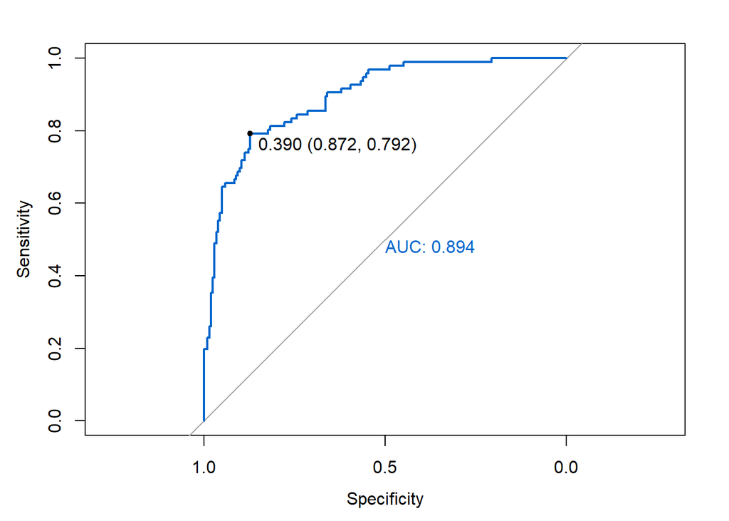

```r
result_forward <- Valid_ROC(XY$event, forward_model$fitted.values, graph = T)
```

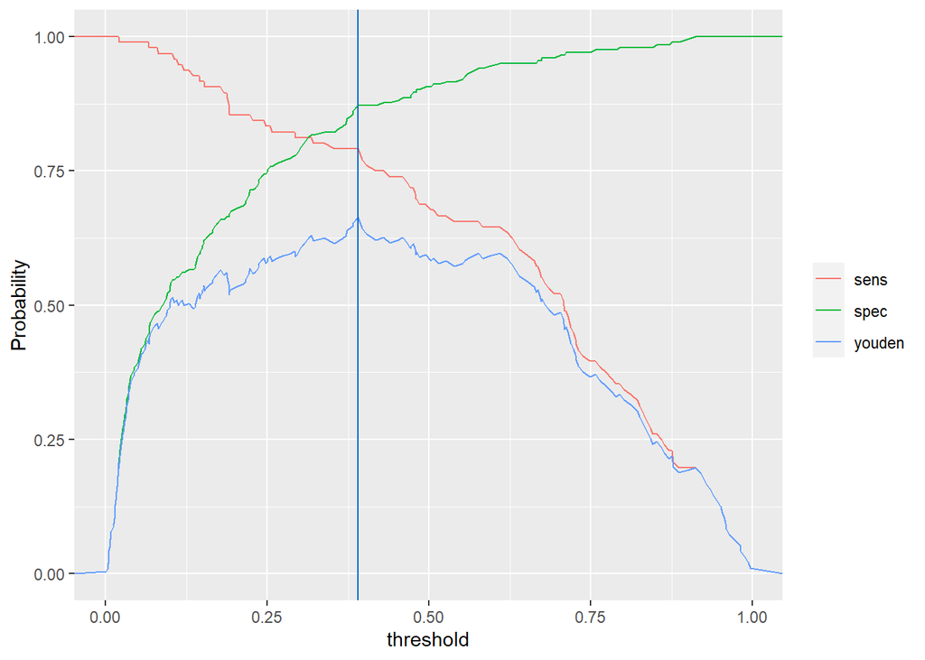

```r
result_forward$graph
```

##### 3.3. Comparaison des résultats

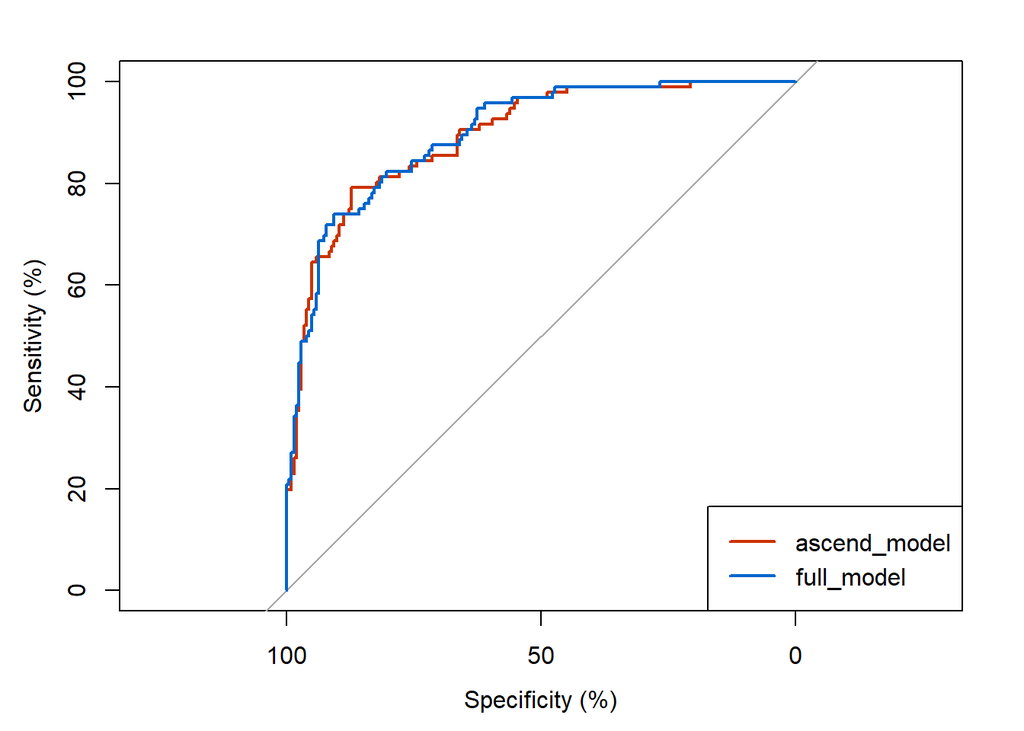

```r
roc1 <- plot.roc(factor(XY$event),forward_model$fitted.values, percent = T, col = '#CC3300')
roc2 <- lines.roc(factor(XY$event),full_model$fitted.values, percent=T, col="#0066CC",  print.thres=TRUE)
legend("bottomright", legend=c("ascend_model", "full_model"), col=c('#CC3300', "#0066CC"), lwd=2)
```

```r
result_forward$result
```

```
##                Confusion
## Accuracy       0.8461538
## AccuracyLower  0.8001752
## AccuracyUpper  0.8851110
## Sensitivity    0.8719212
## Specificity    0.7916667
## Pos Pred Value 0.8984772
## Neg Pred Value 0.7450980
## F1             0.8850000
## Threshold      0.3902202
```

- En utilisant les seuils calculés par l’indice de Youden, les résultats sont les suivants :

```r
kable(result_forward$result,align = rep("c", ncol(result_forward$result))) %>%
  kable_styling(bootstrap_options = "striped", full_width = F, position = "center")
```

|  | Confusion |
| --- | --- |
| Accuracy | 0.8461538 |
| AccuracyLower | 0.8001752 |
| AccuracyUpper | 0.8851110 |
| Sensitivity | 0.8719212 |
| Specificity | 0.7916667 |
| Pos Pred Value | 0.8984772 |
| Neg Pred Value | 0.7450980 |
| F1 | 0.8850000 |
| Threshold | 0.3902202 |

#### 4 Validation croisée

##### 4.1. Les objectifs

###### 4.1.1 Les résultats

```r
kable(resultat_roc,align = rep("c", ncol(resultat_roc))) %>%
  kable_styling(bootstrap_options = "striped", full_width = F, position = "center")
```

|  | kfold1 | kfold2 | kfold3 | kfold4 | kfold5 |
| --- | --- | --- | --- | --- | --- |
| AUC_lower | 0.8901622 | 0.8524461 | 0.8804237 | 0.9202547 | 0.7920291 |
| AUC | 0.9434211 | 0.9396662 | 0.9434211 | 0.9640565 | 0.8768293 |
| AUC_upper | 0.9966799 | 1.0000000 | 1.0000000 | 1.0000000 | 0.9616294 |
| youden | 0.8000000 | 0.8254172 | 0.7921053 | 0.8498074 | 0.6817073 |

```r
kable(resultat_res,align = rep("c", ncol(resultat_roc))) %>%
  kable_styling(bootstrap_options = "striped", full_width = F, position = "center")
```

|  | kfold1 | kfold2 | kfold3 | kfold4 | kfold5 |
| --- | --- | --- | --- | --- | --- |
| Accuracy | 0.8644068 | 0.9000000 | 0.9152542 | 0.9166667 | 0.8032787 |
| AccuracyLower | 0.7501960 | 0.7949423 | 0.8132057 | 0.8161422 | 0.6815788 |
| AccuracyUpper | 0.9395965 | 0.9624087 | 0.9719087 | 0.9723867 | 0.8940058 |
| Sensitivity | 0.8000000 | 0.8780488 | 0.9500000 | 0.9024390 | 0.7317073 |
| Specificity | 1.0000000 | 0.9473684 | 0.8421053 | 0.9473684 | 0.9500000 |
| Pos Pred Value | 1.0000000 | 0.9729730 | 0.9268293 | 0.9736842 | 0.9677419 |
| Neg Pred Value | 0.7037037 | 0.7826087 | 0.8888889 | 0.8181818 | 0.6333333 |
| F1 | 0.8888889 | 0.9230769 | 0.9382716 | 0.9367089 | 0.8333333 |
| Threshold | 0.2389551 | 0.2757672 | 0.5724130 | 0.3098594 | 0.2658856 |

###### 4.1.2 Conclusion

En conclusion voilà comment nous pouvons interpréter les différents paramètres:

Seuil : On voit que les valeurs de seuil varient beaucoup d’un échantillon à l’autre, ce qui indique que le modèle peut être sensible à la façon dont les échantillons sont divisés pour la validation croisée.

En résumé, on peut dire que le modèle a une performance globalement bonne, mais que cette performance varie selon les échantillons utilisés pour la validation croisée. Il peut donc être intéressant d’explorer différentes stratégies de validation croisée pour évaluer la stabilité des résultats.